# Chapter 6: Diagnostics

```python
import pandas as pd
import numpy as np
import matplotlib.pyplot as plt
import scipy as sp
import statsmodels.api as sm
import statsmodels.formula.api as smf
import seaborn as sns
%matplotlib inline
%precision 5
```

```
'%.5f'
```

## Check Error Assumptions

Read in the data for the example:

```python
savings = pd.read_csv("data/savings.csv",index_col=0)
savings.head()
```

|  | sr | pop15 | pop75 | dpi | ddpi |
| --- | --- | --- | --- | --- | --- |
| Australia | 11.43 | 29.35 | 2.87 | 2329.68 | 2.87 |
| Austria | 12.07 | 23.32 | 4.41 | 1507.99 | 3.93 |
| Belgium | 13.17 | 23.80 | 4.43 | 2108.47 | 3.82 |
| Bolivia | 5.75 | 41.89 | 1.67 | 189.13 | 0.22 |
| Brazil | 12.88 | 42.19 | 0.83 | 728.47 | 4.56 |

```python
lmod = smf.ols(formula='sr ~ pop15 + pop75 + dpi + ddpi', data=savings).fit()
lmod.summary()
```

OLS Regression Results

| Dep. Variable: | sr | R-squared: | 0.338 |
| --- | --- | --- | --- |
| Model: | OLS | Adj. R-squared: | 0.280 |
| Method: | Least Squares | F-statistic: | 5.756 |
| Date: | Wed, 26 Sep 2018 | Prob (F-statistic): | 0.000790 |
| Time: | 11:15:04 | Log-Likelihood: | -135.10 |
| No. Observations: | 50 | AIC: | 280.2 |
| Df Residuals: | 45 | BIC: | 289.8 |
| Df Model: | 4 |  |  |
| Covariance Type: | nonrobust |  |  |

|  | coef | std err | t | P>\|t\| | [0.025 | 0.975] |
| --- | --- | --- | --- | --- | --- | --- |
| Intercept | 28.5661 | 7.355 | 3.884 | 0.000 | 13.753 | 43.379 |
| pop15 | -0.4612 | 0.145 | -3.189 | 0.003 | -0.753 | -0.170 |
| pop75 | -1.6915 | 1.084 | -1.561 | 0.126 | -3.874 | 0.491 |
| dpi | -0.0003 | 0.001 | -0.362 | 0.719 | -0.002 | 0.002 |
| ddpi | 0.4097 | 0.196 | 2.088 | 0.042 | 0.015 | 0.805 |

| Omnibus: | 0.866 | Durbin-Watson: | 1.934 |
| --- | --- | --- | --- |
| Prob(Omnibus): | 0.649 | Jarque-Bera (JB): | 0.493 |
| Skew: | 0.241 | Prob(JB): | 0.782 |
| Kurtosis: | 3.064 | Cond. No. | 2.04e+04 |

Warnings:  
[1] Standard Errors assume that the covariance matrix of the errors is correctly specified.  
[2] The condition number is large, 2.04e+04. This might indicate that there are  
strong multicollinearity or other numerical problems.

The simple residual-fitted plot:

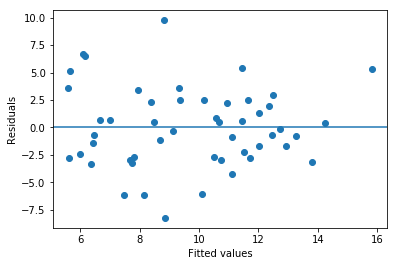

```python
plt.scatter(lmod.fittedvalues, lmod.resid)
plt.ylabel("Residuals")
plt.xlabel("Fitted values")
plt.axhline(0)
```

This plot is slightly better for checking for constant variance:

```
Text(0.5,0,'Fitted values')
```

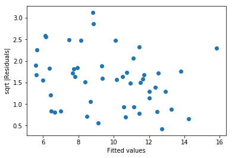

```python
plt.scatter(lmod.fittedvalues, np.sqrt(abs(lmod.resid)))
plt.ylabel("sqrt |Residuals|")
plt.xlabel("Fitted values")
```

Check that there is no significant relationship:

```python
ddf = pd.DataFrame({'x':lmod.fittedvalues,'y':np.sqrt(abs(lmod.resid))})
dmod = smf.ols('y ~ x',data=ddf).fit()
dmod.summary()
```

OLS Regression Results

| Dep. Variable: | y | R-squared: | 0.061 |
| --- | --- | --- | --- |
| Model: | OLS | Adj. R-squared: | 0.041 |
| Method: | Least Squares | F-statistic: | 3.117 |
| Date: | Wed, 26 Sep 2018 | Prob (F-statistic): | 0.0838 |
| Time: | 11:15:04 | Log-Likelihood: | -47.153 |
| No. Observations: | 50 | AIC: | 98.31 |
| Df Residuals: | 48 | BIC: | 102.1 |
| Df Model: | 1 |  |  |
| Covariance Type: | nonrobust |  |  |

|  | coef | std err | t | P>\|t\| | [0.025 | 0.975] |
| --- | --- | --- | --- | --- | --- | --- |
| Intercept | 2.1622 | 0.348 | 6.215 | 0.000 | 1.463 | 2.862 |
| x | -0.0614 | 0.035 | -1.766 | 0.084 | -0.131 | 0.009 |

| Omnibus: | 1.170 | Durbin-Watson: | 2.050 |
| --- | --- | --- | --- |
| Prob(Omnibus): | 0.557 | Jarque-Bera (JB): | 1.184 |
| Skew: | 0.273 | Prob(JB): | 0.553 |
| Kurtosis: | 2.479 | Cond. No. | 39.2 |

Warnings:  
[1] Standard Errors assume that the covariance matrix of the errors is correctly specified.

Simulate some residual-fitted plots:

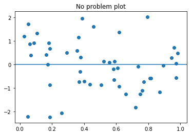

```python
n = 50
x = np.random.sample(n)
y = np.random.normal(size=n)
plt.scatter(x,y)
plt.title("No problem plot")
plt.axhline(0)
```

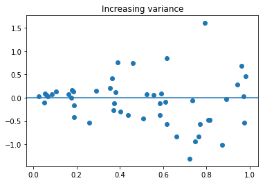

```python
plt.scatter(x,y*x)
plt.title("Increasing variance")
plt.axhline(0)
```

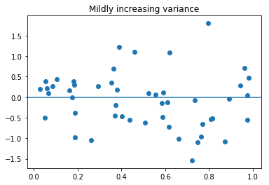

```python
plt.scatter(x,y*np.sqrt(x))
plt.title("Mildly increasing variance")
plt.axhline(0)
```

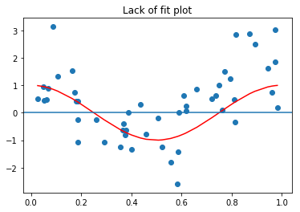

```python
y = np.cos(2*x*np.pi) + np.random.normal(size=n)
plt.scatter(x,y)
plt.title("Lack of fit plot")
sx = np.sort(x)
plt.plot(sx,np.cos(2*sx*np.pi),c='red')
plt.axhline(0)
```

Plots of residuals against predictors:

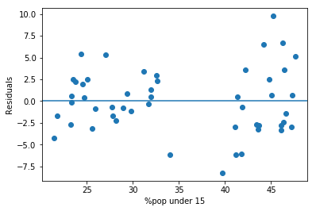

```python
plt.scatter(savings.pop15, lmod.resid)
plt.xlabel("%pop under 15")
plt.ylabel("Residuals")
plt.axhline(0)
```

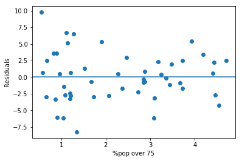

```python
plt.scatter(savings.pop75, lmod.resid)
plt.xlabel("%pop over 75")
plt.ylabel("Residuals")
plt.axhline(0)
```

Check for equality of the variances in the two groups seen in pop15

```python
numres = lmod.resid[savings.pop15 > 35]
denres = lmod.resid[savings.pop15 < 35]
fstat = np.var(numres,ddof=1)/np.var(denres,ddof=1)
2*(1-sp.stats.f.cdf(fstat,len(numres)-1,len(denres)-1))
```

```
0.013575950424159933
```

Do the residual fitted plot for the Galapagos data:

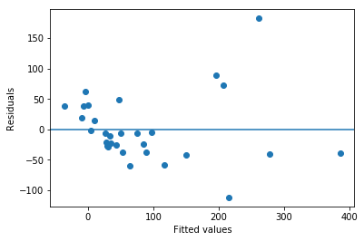

```python
gala = pd.read_csv("data/gala.csv")
gmod = smf.ols(formula='Species ~ Area + Elevation + Nearest + Scruz  + Adjacent', data=gala).fit()
plt.scatter(gmod.fittedvalues, gmod.resid)
plt.ylabel("Residuals")
plt.xlabel("Fitted values")
plt.axhline(0)
```

See how transformation improves the plot:

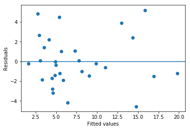

```python
gmod = smf.ols(formula='np.sqrt(Species) ~ Area + Elevation + Nearest + Scruz  + Adjacent', data=gala).fit()
plt.scatter(gmod.fittedvalues, gmod.resid)
plt.ylabel("Residuals")
plt.xlabel("Fitted values")
plt.axhline(0)
```

Check the QQ plot of the residuals. Plot is assigned to foo so it doesn't print twice.

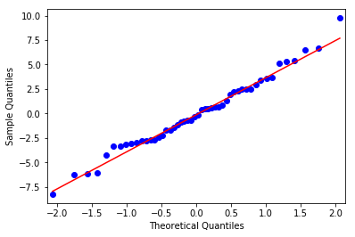

```python
foo = sm.qqplot(lmod.resid, line="q")
```

Histogram is not a good way to check:

```
Text(0.5,0,'Residuals')
```

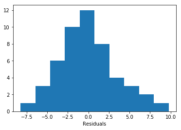

```python
plt.hist(lmod.resid)
plt.xlabel("Residuals")
```

Generate some random QQ plots from known distributions:

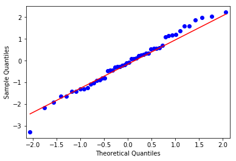

```python
foo = sm.qqplot(np.random.normal(size=50),line="q")
```

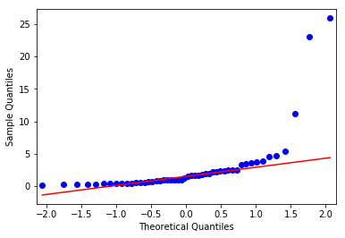

```python
foo = sm.qqplot(np.exp(np.random.normal(size=50)),line="q")
```

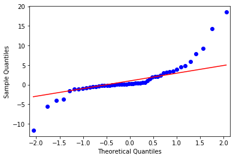

```python
foo = sm.qqplot(np.random.standard_t(1,size=50),line="q")
```

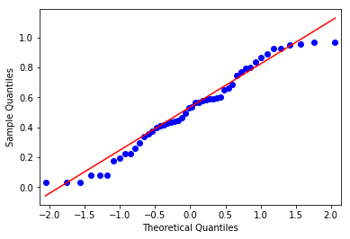

```python
foo = sm.qqplot(np.random.sample(size=50),line="q")
```

Do the Shapiro test - second value is the p-value

```python
sp.stats.shapiro(lmod.resid)
```

```
(0.98698, 0.85240)
```

## Correlated Errors

```python
globwarm = pd.read_csv("data/globwarm.csv")
globwarm.head()
```

|  | nhtemp | wusa | jasper | westgreen | chesapeake | tornetrask | urals | mongolia | tasman | year |
| --- | --- | --- | --- | --- | --- | --- | --- | --- | --- | --- |
| 0 | NaN | -0.66 | -0.03 | 0.03 | -0.66 | 0.33 | -1.49 | 0.83 | -0.12 | 1000 |
| 1 | NaN | -0.63 | -0.07 | 0.09 | -0.67 | 0.21 | -1.44 | 0.96 | -0.17 | 1001 |
| 2 | NaN | -0.60 | -0.11 | 0.18 | -0.67 | 0.13 | -1.39 | 0.99 | -0.22 | 1002 |
| 3 | NaN | -0.55 | -0.14 | 0.30 | -0.68 | 0.08 | -1.34 | 0.95 | -0.26 | 1003 |
| 4 | NaN | -0.51 | -0.15 | 0.41 | -0.68 | 0.06 | -1.30 | 0.87 | -0.31 | 1004 |

```python
lmod = smf.ols(formula='nhtemp ~ wusa + jasper + westgreen + chesapeake + tornetrask + urals + mongolia + tasman',
               data=globwarm).fit()
lmod.summary()
```

OLS Regression Results

| Dep. Variable: | nhtemp | R-squared: | 0.476 |
| --- | --- | --- | --- |
| Model: | OLS | Adj. R-squared: | 0.446 |
| Method: | Least Squares | F-statistic: | 15.47 |
| Date: | Wed, 26 Sep 2018 | Prob (F-statistic): | 5.03e-16 |
| Time: | 11:15:05 | Log-Likelihood: | 50.995 |
| No. Observations: | 145 | AIC: | -83.99 |
| Df Residuals: | 136 | BIC: | -57.20 |
| Df Model: | 8 |  |  |
| Covariance Type: | nonrobust |  |  |

|  | coef | std err | t | P>\|t\| | [0.025 | 0.975] |
| --- | --- | --- | --- | --- | --- | --- |
| Intercept | -0.2426 | 0.027 | -8.980 | 0.000 | -0.296 | -0.189 |
| wusa | 0.0774 | 0.043 | 1.803 | 0.074 | -0.008 | 0.162 |
| jasper | -0.2288 | 0.078 | -2.929 | 0.004 | -0.383 | -0.074 |
| westgreen | 0.0096 | 0.042 | 0.229 | 0.819 | -0.073 | 0.092 |
| chesapeake | -0.0321 | 0.034 | -0.943 | 0.347 | -0.099 | 0.035 |
| tornetrask | 0.0927 | 0.045 | 2.057 | 0.042 | 0.004 | 0.182 |
| urals | 0.1854 | 0.091 | 2.027 | 0.045 | 0.005 | 0.366 |
| mongolia | 0.0420 | 0.046 | 0.917 | 0.361 | -0.049 | 0.133 |
| tasman | 0.1155 | 0.030 | 3.834 | 0.000 | 0.056 | 0.175 |

| Omnibus: | 12.501 | Durbin-Watson: | 0.817 |
| --- | --- | --- | --- |
| Prob(Omnibus): | 0.002 | Jarque-Bera (JB): | 17.388 |
| Skew: | 0.490 | Prob(JB): | 0.000168 |
| Kurtosis: | 4.384 | Cond. No. | 12.9 |

Warnings:  
[1] Standard Errors assume that the covariance matrix of the errors is correctly specified.

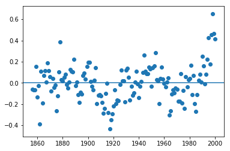

```python
plt.scatter(globwarm.year[lmod.resid.keys()], lmod.resid)
plt.axhline(0)
```

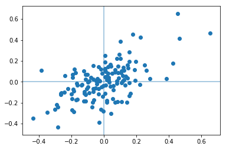

```python
plt.scatter(lmod.resid.iloc[:-1],lmod.resid.iloc[1:])
plt.axhline(0,alpha=0.5)
plt.axvline(0,alpha=0.5)
```

This is the statistic. P-values do not seem to be available. 2 is considered null but less than 1 is a sign of a problem.

```python
sm.stats.stattools.durbin_watson(lmod.resid)
```

```
0.8166063726402724
```

## Finding Unusual Observations

```python
lmod = smf.ols(formula='sr ~ pop15 + pop75 + dpi + ddpi', data=savings).fit()
diagv = lmod.get_influence()
hatv = pd.Series(diagv.hat_matrix_diag, savings.index)
hatv.head()
```

```
Australia    0.067713
Austria      0.120384
Belgium      0.087482
Bolivia      0.089471
Brazil       0.069559
dtype: float64
```

Make the half-normal plot:

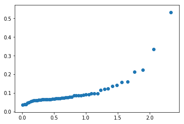

```python
n=50
ix = np.arange(1,n+1)
halfq = sp.stats.norm.ppf((n+ix)/(2*n+1)),
plt.scatter(halfq, np.sort(hatv))
```

Should tag these on the plot

```python
hatv.sort_values().iloc[-5:]
```

```
South Rhodesia    0.160809
Ireland           0.212236
Japan             0.223310
United States     0.333688
Libya             0.531457
dtype: float64
```

One of the built-in plots. Not sure about residuals^2 as a diagnostic.

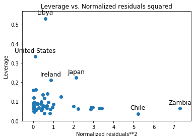

```python
foo = sm.graphics.plot_leverage_resid2(lmod)
```

Would prefer R style plot here.

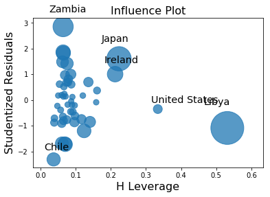

```python
foo = sm.graphics.influence_plot(lmod)
```

Make a QQ plot of the Pearson residuals. These are not the same as the standardised residuals in R.

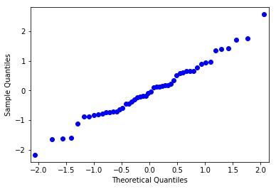

```python
foo = sm.qqplot(lmod.resid_pearson)
```

Make the example plots with outliers. (Seems like this could be done more neatly)

```python
np.random.seed(123)
testdata = pd.DataFrame({'x' : np.arange(1,11), 'y' : np.arange(1,11) + np.random.normal(size=10)})
p1 = pd.DataFrame({'x': [5.5], 'y':[12]})
alldata = testdata.append(p1,ignore_index=True)
```

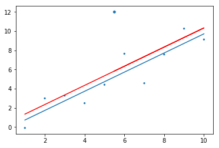

```python
marksize = np.ones(11)
marksize[10] = 3
plt.scatter(alldata.x, alldata.y, s= marksize*5)
slope, intercept = np.polyfit(testdata.x, testdata.y,1)
plt.plot(testdata.x, intercept + slope * testdata.x)
slope, intercept = np.polyfit(alldata.x, alldata.y,1)
plt.plot(alldata.x, intercept + slope * alldata.x, color='red')
```

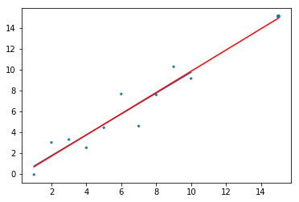

```python
p1 = pd.DataFrame({'x': [15], 'y':[15.1]})
alldata = testdata.append(p1,ignore_index=True)
plt.scatter(alldata.x, alldata.y, s= marksize*5)
slope, intercept = np.polyfit(testdata.x, testdata.y,1)
plt.plot(testdata.x, intercept + slope * testdata.x)
slope, intercept = np.polyfit(alldata.x, alldata.y,1)
plt.plot(alldata.x, intercept + slope * alldata.x, color='red')
```

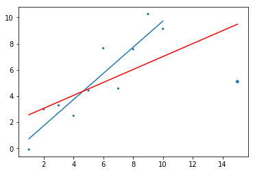

```python
p1 = pd.DataFrame({'x': [15], 'y':[5.1]})
alldata = testdata.append(p1,ignore_index=True)
plt.scatter(alldata.x, alldata.y, s= marksize*5)
slope, intercept = np.polyfit(testdata.x, testdata.y,1)
plt.plot(testdata.x, intercept + slope * testdata.x)
slope, intercept = np.polyfit(alldata.x, alldata.y,1)
plt.plot(alldata.x, intercept + slope * alldata.x, color='red')
```

Create the studentized residuals

```python
stud = pd.Series(diagv.resid_studentized_external, savings.index)
(pd.Series.idxmax(abs(stud)), np.max(abs(stud)))
```

```
('Zambia', 2.8535583382284377)
```

Find the Bonferroni-adjusted critical value:

```python
sp.stats.t.ppf(0.05/(2*50),44)
```

```
-3.525801306486005
```

Star example that has multiple outliers:

```python
star = pd.read_csv("data/star.csv")
star.head()
```

|  | temp | light |
| --- | --- | --- |
| 0 | 4.37 | 5.23 |
| 1 | 4.56 | 5.74 |
| 2 | 4.26 | 4.93 |
| 3 | 4.56 | 5.74 |
| 4 | 4.30 | 5.19 |

Put the line on the plot:

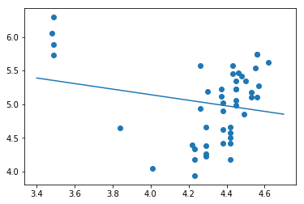

```python
lmod = smf.ols(formula='light ~ temp',data=star).fit()
plt.scatter(star.temp, star.light)
plt.plot([3.4, 4.7], [lmod.params[0] + lmod.params[1]*3.4, lmod.params[0] + lmod.params[1]*4.7])
```

Look for outliers:

```python
stud = lmod.get_influence().resid_studentized_external
np.min(stud), np.max(stud)
```

```
(-2.049392729378057, 1.905847201766315)
```

Fit the line without the four points:

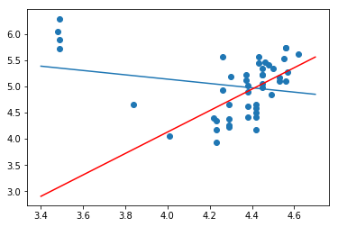

```python
lmodr = smf.ols(formula='light ~ temp',data=star[star.temp > 3.6]).fit()
plt.scatter(star.temp, star.light)
plt.plot([3.4, 4.7], [lmod.params[0] + lmod.params[1]*3.4, lmod.params[0] + lmod.params[1]*4.7])
plt.plot([3.4, 4.7], [lmodr.params[0] + lmodr.params[1]*3.4, lmodr.params[0] + lmodr.params[1]*4.7],color='red')
```

## Influential observations

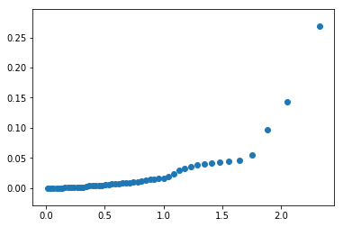

```python
lmod = smf.ols(formula='sr ~ pop15 + pop75 + dpi + ddpi', data=savings).fit()
diagv = lmod.get_influence()
cooks = pd.Series(diagv.cooks_distance[0], savings.index)
n=50
ix = np.arange(1,n+1)
halfq = sp.stats.norm.ppf((n+ix)/(2*n+1)),
plt.scatter(halfq, np.sort(cooks))
```

Would be best placed on the plot.

```python
cooks.sort_values().iloc[-5:]
```

```
Philippines    0.045221
Ireland        0.054396
Zambia         0.096633
Japan          0.142816
Libya          0.268070
dtype: float64
```

First column is the all data estimates and second is one without largest cook stat.

```python
lmodi = smf.ols(formula='sr ~ pop15 + pop75 + dpi + ddpi', data=savings[cooks < 0.2]).fit()
pd.DataFrame({'with':lmod.params,'without':lmodi.params})
```

|  | with | without |
| --- | --- | --- |
| Intercept | 28.566087 | 24.524046 |
| pop15 | -0.461193 | -0.391440 |
| pop75 | -1.691498 | -1.280867 |
| dpi | -0.000337 | -0.000319 |
| ddpi | 0.409695 | 0.610279 |

Would be better to autodetect extreme cases and label them. Note that dfbetas is the change in standard errors and not the change in coefficient as in R.

```
Text(48,-0.483244,'Libya')
```

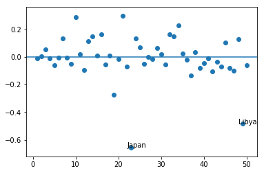

```python
p15d = diagv.dfbetas[:,1]
plt.scatter(np.arange(1,51),p15d)
plt.axhline(0)
ix = 22
plt.annotate(savings.index[ix],(ix, p15d[ix]))
ix = 48
plt.annotate(savings.index[ix],(ix, p15d[ix]))
```